# Projeto Final FCM: Análise descritiva em um dataset sobre diabetes

Guilherme Rodrigues e Beatriz Magiore

2023-07-13

# Introdução

O conjunto de dados *Diabetes Prediction* disponível em https://www.kaggle.com/datasets/iammustafatz/diabetes-prediction-dataset?select=diabetes_prediction_dataset.csv consiste em uma compilação de informações médicas e demográficas de 100 mil pacientes. Esses dados podem ser utilizados para realizar análises descritivas e exploratórias visando compreender melhor os fatores associados à doença.

A análise descritiva desses dados, considerando estatísticas básicas, distribuições, relações entre variáveis e comparação entre grupos, pode auxiliar na compreensão de fatores relacionados ao desenvolvimento da doença. Além disso, essas análises podem auxiliar no desenvolvimento de estratégias de prevenção e tratamento mais eficazes para o diabetes.

Vamos carregar as bibliotecas:

```r
library(ggplot2)
library(tidyr)
library(dplyr)
library(rcartocolor)
```

Chamando o conjunto de dados, temos:

```r
dados <- read.csv("./diabetes_prediction_dataset.csv")
head(dados)
```

```
##   gender age hypertension heart_disease smoking_history   bmi HbA1c_level
## 1 Female  80            0             1           never 25.19         6.6
## 2 Female  54            0             0         No Info 27.32         6.6
## 3   Male  28            0             0           never 27.32         5.7
## 4 Female  36            0             0         current 23.45         5.0
## 5   Male  76            1             1         current 20.14         4.8
## 6 Female  20            0             0           never 27.32         6.6
##   blood_glucose_level diabetes
## 1                 140        0
## 2                  80        0
## 3                 158        0
## 4                 155        0
## 5                 155        0
## 6                  85        0
```

```r
nrow(dados)
```

```
## [1] 100000
```

Acompanhados da condição de diabetes (1 para a presença e 0 para ausência), os atributos abrangem uma variedade de características, incluindo idade, gênero, índice de massa corporal (IMC), hipertensão, doenças cardíacas, histórico de tabagismo, nível de HbA1c (hemoglobina glicada) e nível de glicose no sangue.

As variáveis podem ser divididas em numéricas e categóricas.

- Variáveis numéricas:
  - idade
  - IMC
  - nível de HbA1c
  - nível de glicose no sangue
- Variáveis categóricas:
  - gênero
  - hipertensão
  - doenças cardíacas
  - histórico de tabagismo
  - diabetes

Exibindo informações do *dataframe*:

```r
str(sapply(dados, unique))
```

```
## List of 9
##  $ gender             : chr [1:3] "Female" "Male" "Other"
##  $ age                : num [1:102] 80 54 28 36 76 20 44 79 42 32 ...
##  $ hypertension       : int [1:2] 0 1
##  $ heart_disease      : int [1:2] 1 0
##  $ smoking_history    : chr [1:6] "never" "No Info" "current" "former" ...
##  $ bmi                : num [1:4247] 25.2 27.3 23.4 20.1 19.3 ...
##  $ HbA1c_level        : num [1:18] 6.6 5.7 5 4.8 6.5 6.1 6 5.8 3.5 6.2 ...
##  $ blood_glucose_level: int [1:18] 140 80 158 155 85 200 145 100 130 160 ...
##  $ diabetes           : int [1:2] 0 1
```

Como alguams variáveis são categóricas, primeiramente vamos fazer uma conversão da representação dessas variáveis, para então fazermos um resumo estatístico dos dados:

```r
dados %>%
  mutate(
    gender = factor(gender),
    hypertension = factor(hypertension),
    heart_disease = factor(heart_disease),
    smoking_history = factor(smoking_history),
    diabetes = factor(diabetes)
  ) %>%
  summary()
```

```
##     gender           age        hypertension heart_disease    smoking_history
##  Female:58552   Min.   : 0.08   0:92515      0:96058       current    : 9286
##  Male  :41430   1st Qu.:24.00   1: 7485      1: 3942       ever       : 4004
##  Other :   18   Median :43.00                              former     : 9352
##                 Mean   :41.89                              never      :35095
##                 3rd Qu.:60.00                              No Info    :35816
##                 Max.   :80.00                              not current: 6447
##       bmi         HbA1c_level    blood_glucose_level diabetes
##  Min.   :10.01   Min.   :3.500   Min.   : 80.0       0:91500
##  1st Qu.:23.63   1st Qu.:4.800   1st Qu.:100.0       1: 8500
##  Median :27.32   Median :5.800   Median :140.0
##  Mean   :27.32   Mean   :5.528   Mean   :138.1
##  3rd Qu.:29.58   3rd Qu.:6.200   3rd Qu.:159.0
##  Max.   :95.69   Max.   :9.000   Max.   :300.0
```

# Primeiras análises descritivas dos dados

Vamos fazer uma análise individual das variáveis do *dataframe*

```r
# Definindo um tema padrão para os gráficos das análises
theme_set(theme_minimal(base_size = 12) + theme(text = element_text(face = "bold"),
                                             axis.title.x = element_text(face = "bold"),
                                             axis.title.y = element_text(face = "bold"),
                                             legend.title = element_text(face = "bold"),
                                             legend.text = element_text(face = "bold"),
                                             plot.title = element_text(hjust = 0.5)))
```

Uma análise preliminar relacionada a distribuição de pacientes divididos por gênero foi realizada, e os resultados foram obtidos a partir do gráfico de barras abaixo.

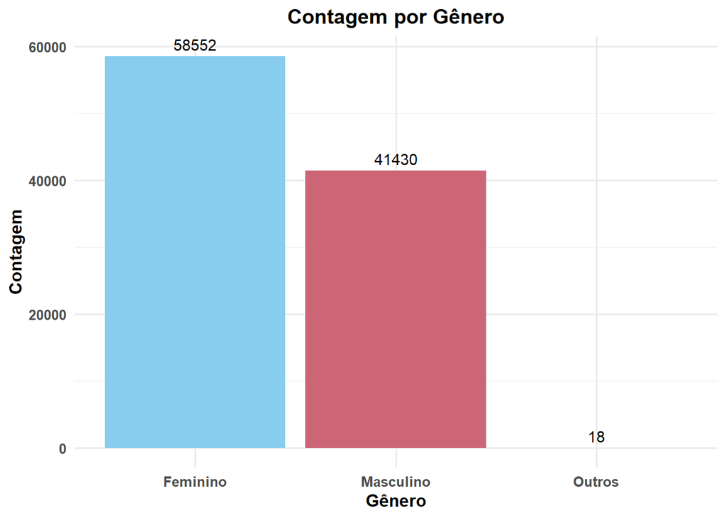

```r
dados %>%
  ggplot(aes(x = gender, fill = gender)) +
    geom_bar() +
    geom_text(stat = "count", aes(label = after_stat(count)), vjust = -0.5, color = "black")+
    scale_fill_manual(values = rcartocolor::carto_pal(3,"Safe"),
                      breaks = c("Female","Male","Others")) +
    labs(title = "Contagem por Gênero") +
    xlab("Gênero") +
    ylab("Contagem") +
    scale_x_discrete(labels = c("Feminino", "Masculino", "Outros"))+
    theme(legend.position = "none")
```

- Com relação a variável *diabetes*, temos que, dos 100 mil pacientes, apenas 8500 possuem diabetes.

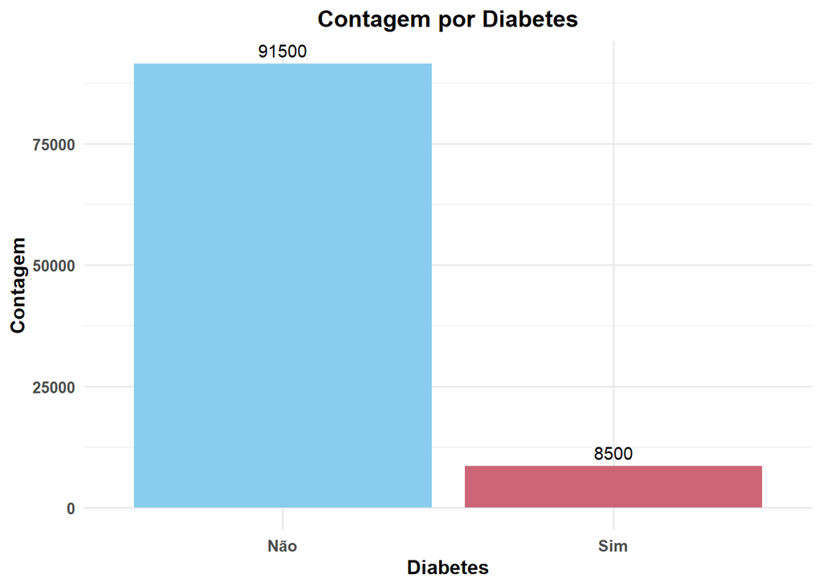

```r
contagem_diabetes <- dados %>%
  count(diabetes) %>%
  mutate(diabetes = factor(diabetes, labels = c("Não", "Sim")))

contagem_diabetes %>%
  ggplot(aes(x = diabetes, y = n, fill = diabetes)) +
    geom_bar(stat = "identity") +
    geom_text(aes(label = n), vjust = -0.5, color = "black") +
    scale_fill_manual(values = rcartocolor::carto_pal(3,"Safe")) +
    labs(title = "Contagem por Diabetes", x = "Diabetes", y = "Contagem")+
    theme(legend.position = "none")
```

- Com relação a variável *smoking_history*, que apresenta as informações acerca do uso de tabaco, temos a classificação:
  - “*Never*”: indivíduos que nunca fumaram;
  - “*Former*”: indivíduos que fumavam mas estão em abstinência há muito tempo;
  - “*Not current*”: indivíduos que costumavam fumar, mas atualmente não fumam;
  - “*Ever*”: indivíduos que já foram fumantes;
  - “*Current*”: indivíduos que fumam atualmente;
  - “*No info*”: indivíduos cujo histórico de tabagismo é desconhecido.

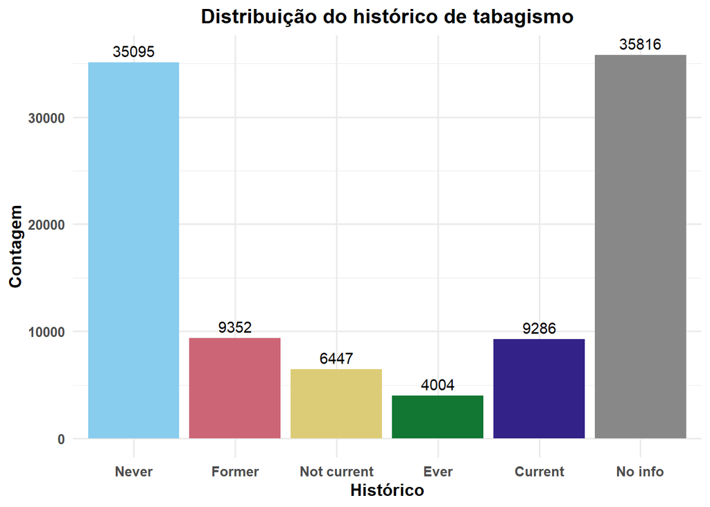

```r
dados_smoking <- dados %>% select(gender, smoking_history, diabetes)

dados_smoking %>%
  ggplot(aes(x = factor(smoking_history,
                        levels = c("never", "former", "not current", "ever", "current", "No Info")),
             fill = smoking_history)) +
    geom_bar(stat="count") +
    geom_text(stat = "count", aes(label = after_stat(count)), vjust = -0.5, color = "black") +
    labs(title = "Distribuição do histórico de tabagismo", x = "Histórico", y = "Contagem")+
    scale_fill_manual(values = rcartocolor::carto_pal(6,"Safe"),
                      breaks = c("never", "former", "not current", "ever", "current", "No Info"),
                      label = c("Never", "Former", "Not current", "Ever", "Current", "No info"),
                      name = "Histórico")+
    scale_x_discrete(label = c("Never", "Former", "Not current", "Ever", "Current", "No info"))+
    theme(legend.position = "none")
```

- Com relação a variável *hypertension*, que apresenta as informações acerca de pacientes com hipertensão, temos que 7485 possuem tal condição.

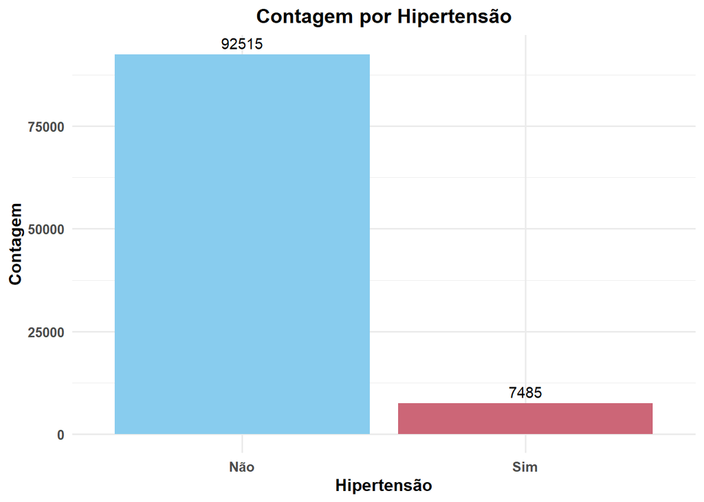

```r
contagem_hipertensao <- dados %>%
  count(hypertension) %>%
  mutate(hypertension = factor(hypertension, labels = c("Não", "Sim")))

contagem_hipertensao %>%
  ggplot(aes(x = hypertension, y = n, fill = hypertension)) +
    geom_bar(stat = "identity") +
    geom_text(aes(label = n), vjust = -0.5, color = "black") +
    scale_fill_manual(values = rcartocolor::carto_pal(3,"Safe")) +
    labs(title = "Contagem por Hipertensão", x = "Hipertensão", y = "Contagem")+
    theme(legend.position = "none")
```

- Com relação a variável *heart_desease*, que apresenta as informações acerca de pacientes com doenças cardíacas, temos que 3942 deles possuem alguma doença.

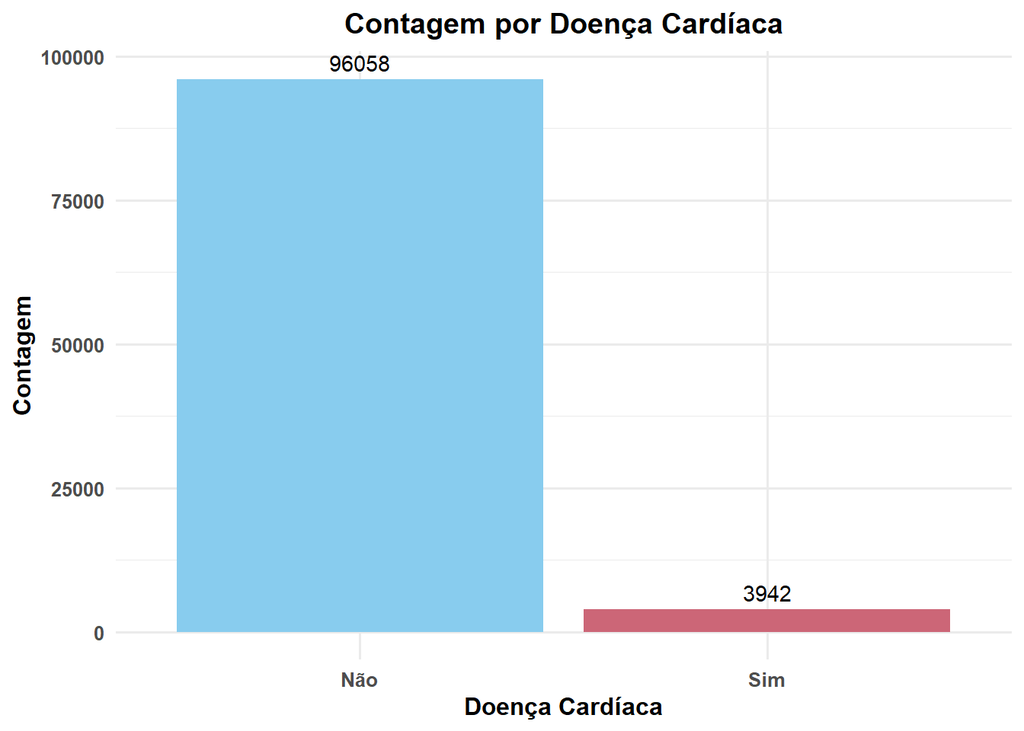

```r
contagem_doencacardiaca <- dados %>%
  count(heart_disease) %>%
  mutate(heart_disease = factor(heart_disease, labels = c("Não", "Sim")))

contagem_doencacardiaca %>%
  ggplot(aes(x = heart_disease, y = n, fill = heart_disease)) +
    geom_bar(stat = "identity") +
    geom_text(aes(label = n), vjust = -0.5, color = "black") +
    scale_fill_manual(values = rcartocolor::carto_pal(3,"Safe")) +
    labs(title = "Contagem por Doença Cardíaca", x = "Doença Cardíaca", y = "Contagem")+
    theme(legend.position = "none")
```

# Análise descritiva considerando as variáveis categóricas

Nesta rodada de análises descritivas vamos mostrar alguns resultados acerca dos dados dicotomizados presentes no *dataset*, isto é, 0 para a ausência e 1 para a presença de determinada doença. Sabemos que a distribuição de probabilidades de variáveis desse tido segue a distribuição de Bernoulli, dada por

$$f(k;p)=p^k(1-p)^{1-k},\quad\text{para
}k\in(0,1)$$
em que $p$ é a probabilidade de sucessos e $1-p$ a probabilidade de fracassos. Além disso, sabemos que o valor esperado e a variância de uma variável aleatória de Bernoulli $X$ é
$$E(X)=p,\quad Var(X)=p(1-p)$$

```r
dados_dicotomicos <- dados %>% select(gender, hypertension, heart_disease, diabetes)
head(dados_dicotomicos)
```

```
##   gender hypertension heart_disease diabetes
## 1 Female            0             1        0
## 2 Female            0             0        0
## 3   Male            0             0        0
## 4 Female            0             0        0
## 5   Male            1             1        0
## 6 Female            0             0        0
```

Uma análise preliminar relacionada a distribuição de pacientes divididos por gênero foi realizada e, como observado mais acima, 18 indivíduos informaram o gênero como *Others*. Como os dados de saúde dessa população podem afetar o andamento de algumas análises como, por exemplo, os cálculos dos coeficientes de variação, analisamos os dados de saúde desta população em específico, para verificar a sua contribuição. A priori, filtramos esta população do conjunto de dados dicotômicos e obtivemos os seguintes resultados:

```r
(dados_dicotomicos %>% filter(gender == "Other"))
```

```
##    gender hypertension heart_disease diabetes
## 1   Other            0             0        0
## 2   Other            0             0        0
## 3   Other            0             0        0
## 4   Other            0             0        0
## 5   Other            0             0        0
## 6   Other            0             0        0
## 7   Other            0             0        0
## 8   Other            0             0        0
## 9   Other            0             0        0
## 10  Other            0             0        0
## 11  Other            0             0        0
## 12  Other            0             0        0
## 13  Other            0             0        0
## 14  Other            0             0        0
## 15  Other            0             0        0
## 16  Other            0             0        0
## 17  Other            0             0        0
## 18  Other            0             0        0
```

Nenhum dos indivíduos que se identificam como *Outro* gênero apresentou alguma das três condições analisadas neste primeiro momento. Desse modo, para evitar problemas como divisão por zero nos cálculos, excluímos estes 18 indivíduos por meio da filtragem, isto é

```r
dados_dicotomicos_others <- dados_dicotomicos %>% filter(gender != "Other")
```

Para avaliar se os pacientes saíram do banco de dados podemos utilizar o comando *grepl*:

```r
gender_other_search <- sum(grepl("Other", dados_dicotomicos_others$gender))
print(gender_other_search)
```

```
## [1] 0
```

Extraindo algumas informações de média, desvio padrão e coeficiente de variação separado por gênero temos que

```r
dados_dicotomicos_exploration <- dados_dicotomicos_others %>%
  group_by(gender) %>%
  summarise(
    media_hypertension=mean(hypertension),
    media_heart_desease = mean(heart_disease),
    media_diabetes = mean(diabetes),
    dp_hypertension=sd(hypertension),
    dp_heart_desease = sd(heart_disease),
    dp_diabetes = sd(diabetes),
    CV_hypertension=dp_hypertension/media_hypertension,
    CV_heart_desease = dp_heart_desease/media_heart_desease,
    CV_diabetes = dp_diabetes/media_diabetes,
    N = n()
  )
(dados_dicotomicos_exploration)
```

```
## # A tibble: 2 × 11
##   gender media…¹ media…² media…³ dp_hy…⁴ dp_he…⁵ dp_di…⁶ CV_hy…⁷ CV_he…⁸ CV_di…⁹
##   <chr>    <dbl>   <dbl>   <dbl>   <dbl>   <dbl>   <dbl>   <dbl>   <dbl>   <dbl>
## 1 Female  0.0717  0.0267  0.0762   0.258   0.161   0.265    3.60    6.04    3.48
## 2 Male    0.0794  0.0574  0.0975   0.270   0.233   0.297    3.41    4.05    3.04
## # … with 1 more variable: N <int>, and abbreviated variable names
## #   ¹media_hypertension, ²media_heart_desease, ³media_diabetes,
## #   ⁴dp_hypertension, ⁵dp_heart_desease, ⁶dp_diabetes, ⁷CV_hypertension,
## #   ⁸CV_heart_desease, ⁹CV_diabetes
```

Podemos observar que, em média, os homens possuem maior prevalência das doenças analisadas, e além disso, a presença destas doenças em homens é mais homogênea do que em mulheres, dado que os coeficientes de variação são mais baixos no gênero masculino.

Realizando uma análise de relação entre a incidência de diabetes em indivíduos com hipertensão

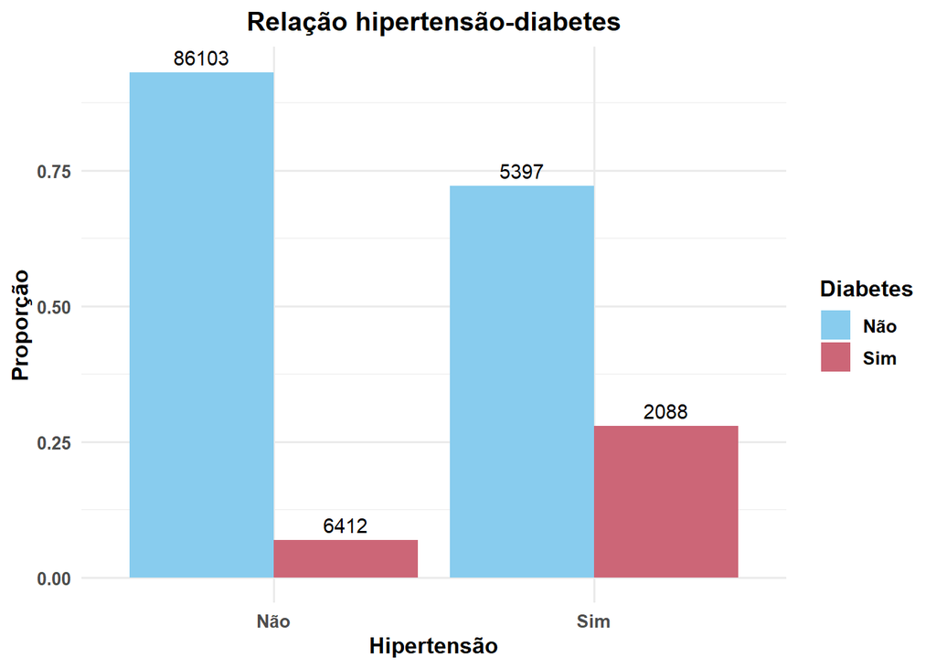

```r
dados_dicotomicos %>%
  group_by(hypertension, diabetes) %>%
  summarise(count = n()) %>%
  mutate(prop = count / sum(count)) %>%
  ggplot(aes(x = factor(hypertension), y = prop, fill = factor(diabetes))) +
    geom_col(position = "dodge") +
    labs(title = "Relação hipertensão-diabetes",
         x = "Hipertensão", y = "Proporção", fill = "Diabetes") +
    scale_fill_manual(values = rcartocolor::carto_pal(4,"Safe"), labels = c("Não", "Sim")) +
    scale_x_discrete(labels = c("Não", "Sim"), breaks = c(0, 1)) +
    geom_text(aes(label = count), position = position_dodge(width = 0.9), vjust = -0.5) +
    theme()
```

E a relação com doenças cardíacas:

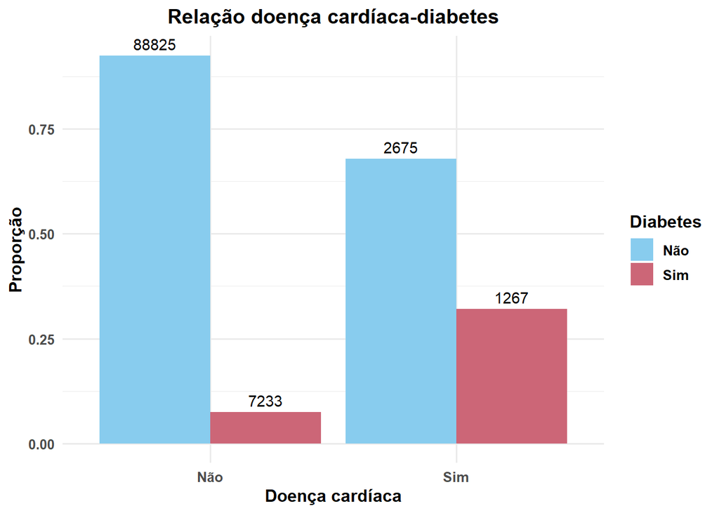

```r
dados_dicotomicos %>%
  group_by(heart_disease, diabetes) %>%
  summarise(count = n()) %>%
  mutate(prop = count / sum(count)) %>%
  ggplot(aes(x = factor(heart_disease), y = prop, fill = factor(diabetes))) +
    geom_col(position = "dodge") +
    labs(title = "Relação doença cardíaca-diabetes",
         x = "Doença cardíaca", y = "Proporção", fill = "Diabetes") +
    scale_fill_manual(values = rcartocolor::carto_pal(4,"Safe"), labels = c("Não", "Sim")) +
    scale_x_discrete(labels = c("Não", "Sim"), breaks = c(0, 1)) +
    geom_text(aes(label = count), position = position_dodge(width = 0.9), vjust = -0.5) +
    theme()
```

Assim, percebemos que pessoas hipertensas e/ou com doenças cardíacas são mais propensas a ter diabetes do que aquelas que não possuem tais condições.

Realizando esta mesma análise com as informações de tabagismo, desconsideramos aqueles classificados como *No info* e agrupamos os indivíduos como os que nunca fumaram, os que já fumaram no passado e os que fumam atualmente.

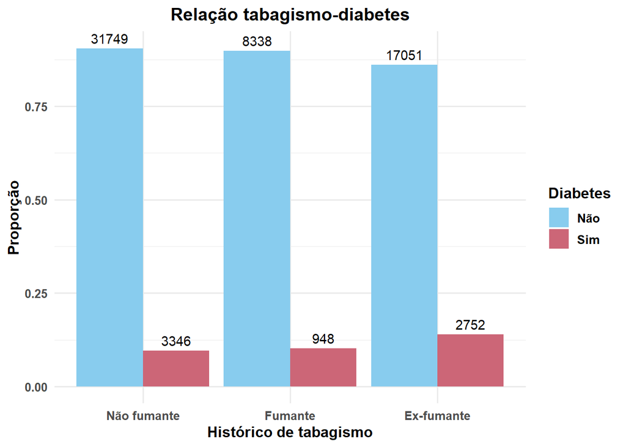

```r
dados_smoking <- dados %>%
  filter(smoking_history != "No Info") %>%
  mutate(smoking_history_redef = case_when(smoking_history == "never" ~ "non-smoker",
                                           smoking_history == "current" ~ "current",
                                           smoking_history %in% c("former", "ever", "not current") ~ "past smoker"))
dados_smoking %>%
  group_by(smoking_history_redef, diabetes) %>%
  summarise(count = n()) %>%
  mutate(prop = count / sum(count)) %>%
  ggplot(aes(x = factor(smoking_history_redef, levels = c("non-smoker", "current", "past smoker")),
             y = prop, fill = factor(diabetes))) +
    geom_col(position = "dodge") +
    labs(title = "Relação tabagismo-diabetes",
         x = "Histórico de tabagismo", y = "Proporção", fill = "Diabetes") +
    scale_fill_manual(values = rcartocolor::carto_pal(6,"Safe"), labels = c("Não", "Sim")) +
    scale_x_discrete(breaks = c("non-smoker", "current", "past smoker"),
                    label = c("Não fumante", "Fumante", "Ex-fumante")) +
    geom_text(aes(label = count), position = position_dodge(width = 0.9), vjust = -0.5) +
    theme()
```

Notamos que a relação do histórico de tabagismo com o diagnóstico de diabetes é muito sutil, sendo levemente maior para aqueles que fumaram no passado e, dessa foma, não é possível estabelecer uma relação concreta entre as duas variáveis..

# Análise descritiva considerando as variáveis numéricas

Agora, nesta rodada de análises, vamos considerar as variáveis numéricas presentes no *dataset*: *age, bmi, HbA1c_level, blood_glucose_level* e as suas relações com a *diabetes*.

A priori vamos analisar a distribuição da faixa etária dos pacientes.

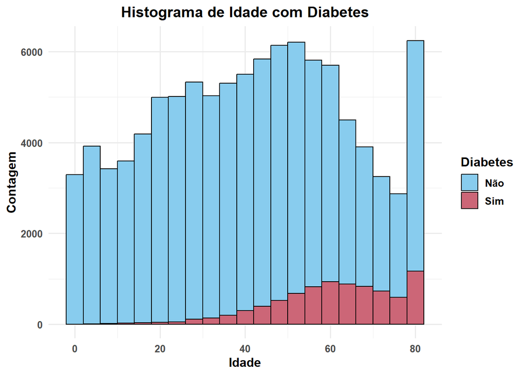

```r
# Histograma
ggplot() +
  geom_histogram(data = dados, aes(x = age, fill = "Não"), binwidth = 4, color = "black") +
  geom_histogram(data = subset(dados, diabetes == 1), aes(x = age, fill = "Sim"),
                 binwidth = 4, color = "black") +
  labs(x = "Idade", y = "Contagem", fill = "Diabetes") +
  scale_fill_manual(values = c("Não" = "#88CCEE", "Sim" = "#CC6677")) +
  ggtitle("Histograma de Idade com Diabetes") +
  theme()
```

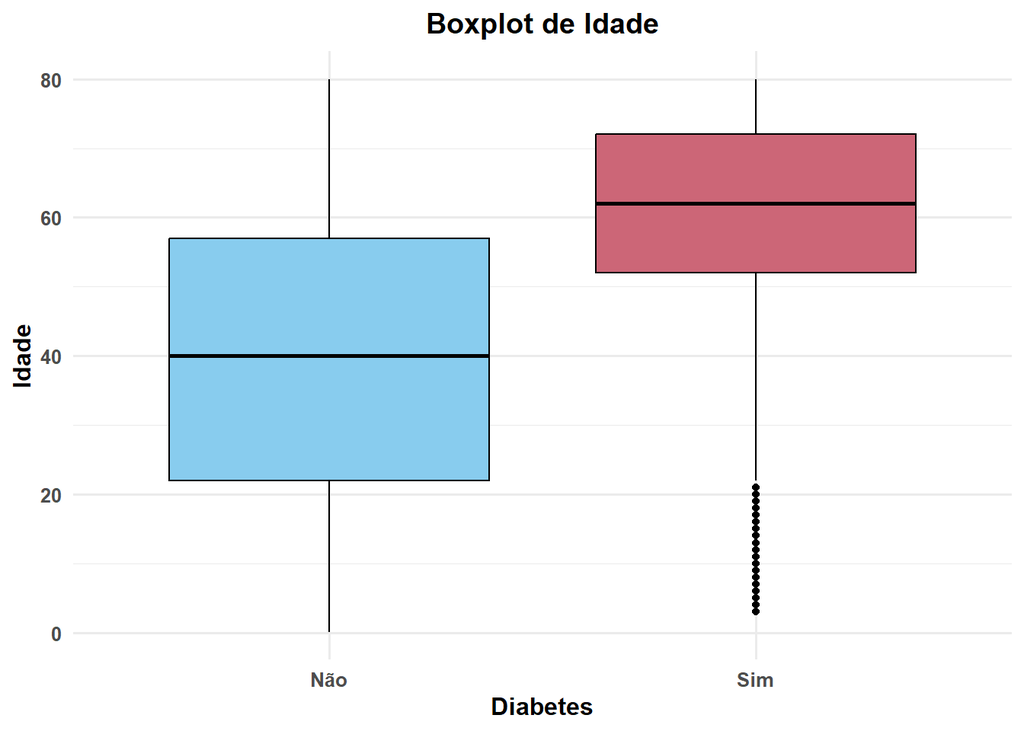

```r
# Boxplot
ggplot(dados, aes(x = factor(diabetes), y = age, fill = factor(diabetes))) +
  geom_boxplot(color = "black") +
  scale_fill_manual(values = c("#88CCEE", "#CC6677")) +
  labs(x = "Diabetes", y = "Idade") +
  scale_x_discrete(breaks = c(0,1), label = c("Não", "Sim")) +
  guides(fill = "none")+
  ggtitle("Boxplot de Idade") +
  theme()
```

A partir do histograma e boxplot, podemos verificar que há uma maior prevalência de diabetes com o aumento da idade dos indivíduos. Enquanto a média de idade dos indivíduos sem diabetes é de 40,1 anos, a dos indivíduos com diabetes é de 60,9 anos.

Analisando a distribuição do IMC dos indivíduos

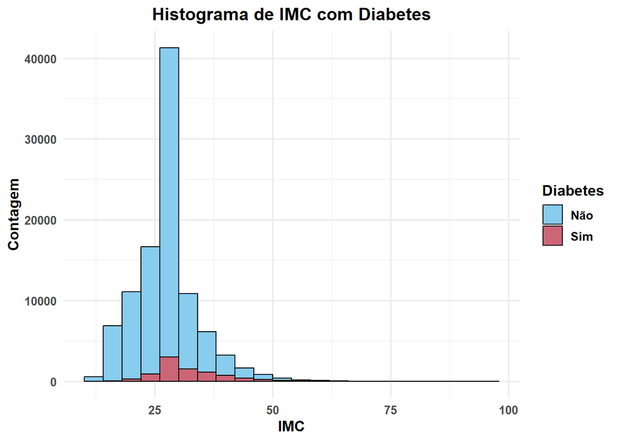

```r
# Histograma
ggplot() +
  geom_histogram(data = dados, aes(x = bmi, fill = "Não"), binwidth = 4, color = "black") +
  geom_histogram(data = subset(dados, diabetes == 1), aes(x = bmi, fill = "Sim"),
                 binwidth = 4, color = "black") +
  labs(x = "IMC", y = "Contagem", fill = "Diabetes") +
  scale_fill_manual(values = c("Não" = "#88CCEE", "Sim" = "#CC6677")) +
  ggtitle("Histograma de IMC com Diabetes") +
  theme()
```

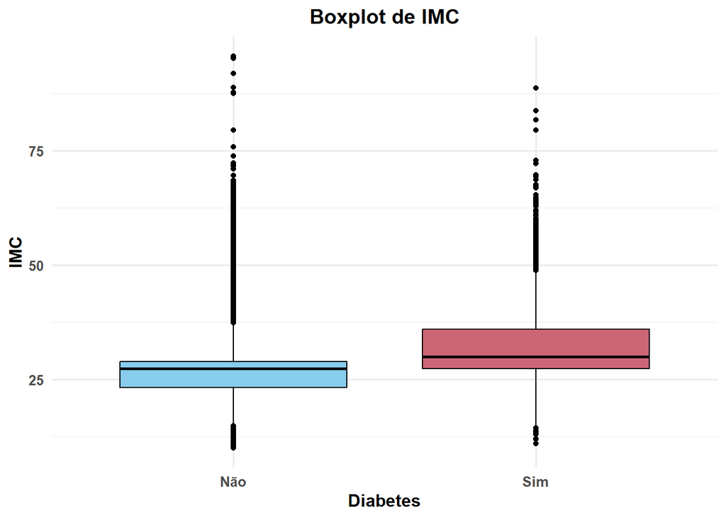

```r
# Boxplot
ggplot(dados, aes(x = factor(diabetes), y = bmi, fill = factor(diabetes))) +
  geom_boxplot(color = "black") +
  scale_fill_manual(values = c("#88CCEE", "#CC6677")) +
  labs(x = "Diabetes", y = "IMC") +
  scale_x_discrete(breaks = c(0,1), label = c("Não", "Sim")) +
  guides(fill = "none")+
  ggtitle("Boxplot de IMC") +
  theme()
```

Como esses gráficos não nos permitem visualizar a real relação entre as variáveis para valores de IMC maiores que 50, representaremos as informações de outro modo para melhor visualização.

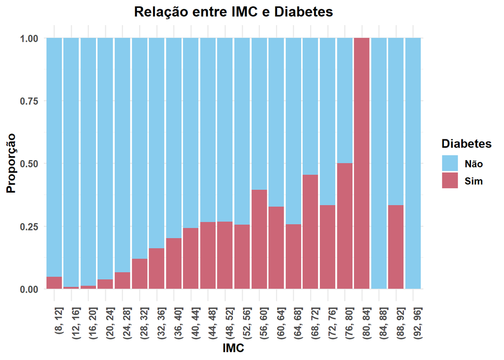

```r
breaks <- seq(0, ceiling(max(dados$bmi)), by = 4)
labels <- sprintf("(%d, %d]", breaks[-length(breaks)], breaks[-1])

dados %>%
  mutate(intervalo_bmi = cut(bmi, breaks = breaks, labels = labels, include.lowest = TRUE))%>%
  ggplot(aes(x = intervalo_bmi, fill = factor(diabetes))) +
  geom_bar(position = "fill") +
  labs(x = "IMC", y = "Proporção", fill = "Diabetes") +
  scale_fill_manual(values = c("#88CCEE", "#CC6677"),label = c("Não", "Sim")) +
  ggtitle("Relação entre IMC e Diabetes") +
  theme(axis.text.x = element_text(angle = 90, hjust = 1))
```

*Obs.:* Embora amplamente utilizado, o IMC é uma medida apenas de peso corporal em relação à altura, tendo grandes limitações significativas como medida isolada de saúde, assim, é preciso ter cuidado ao considerar uma relação individual dessa variável.

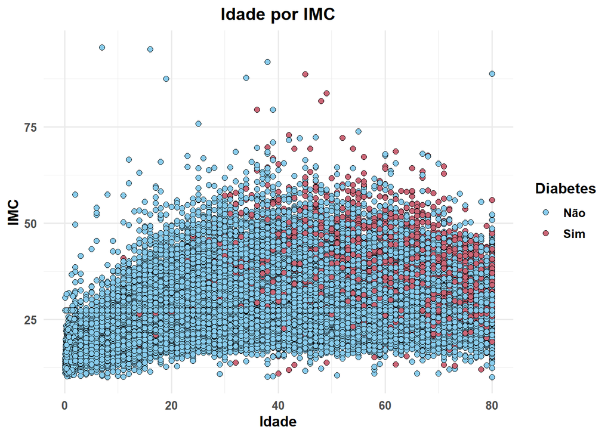

```r
# Scatterplot - Idade-IMC
ggplot(dados, aes(x = age, y = bmi, fill = factor(diabetes))) +
  geom_point(shape = 21, size = 2) +
  labs(x = "Idade", y = "IMC", fill = "Diabetes") +
  ggtitle("Idade por IMC") +
  scale_fill_manual(values = c("#88CCEE", "#CC6677"),
                    breaks = c(0,1), labels = c("Não","Sim")) +
  theme()
```

Agora, ao visualizar a distribuição dos casos de diabetes em relação à idade e ao IMC, é possível estabelecer melhor relação com essas variáveis e notar que para os indivíduos com idade maior que 40 anos e IMC maior que 30, a incidência de diabetes aumenta drasticamente.

Analisando os níveis de hemoglobina glicada dos pacientes:

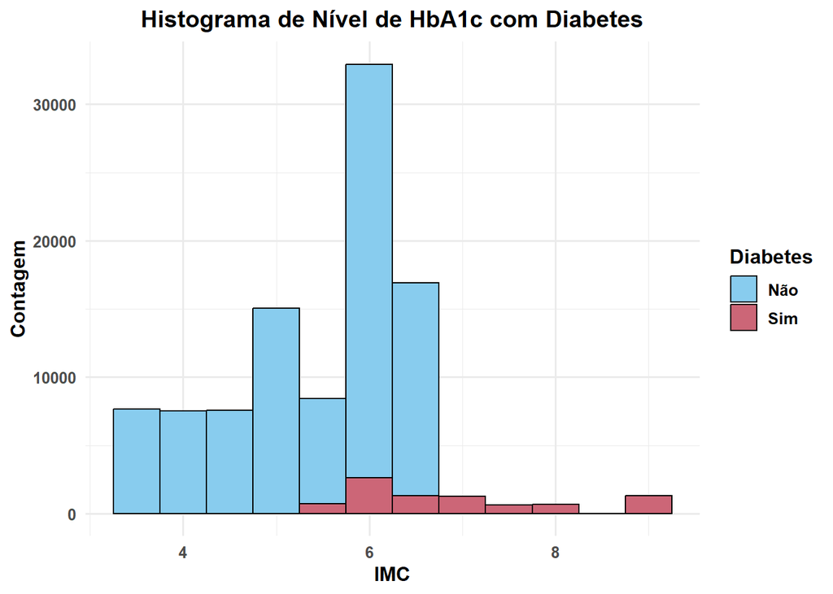

```r
# Histograma
ggplot() +
  geom_histogram(data = dados, aes(x = HbA1c_level, fill = "Não"), binwidth = 0.5, color = "black") +
  geom_histogram(data = subset(dados, diabetes == 1), aes(x = HbA1c_level, fill = "Sim"), binwidth = 0.5, color = "black") +
  labs(x = "IMC", y = "Contagem", fill = "Diabetes") +
  scale_fill_manual(values = c("Não" = "#88CCEE", "Sim" = "#CC6677")) +
  ggtitle("Histograma de Nível de HbA1c com Diabetes") +
  theme()
```

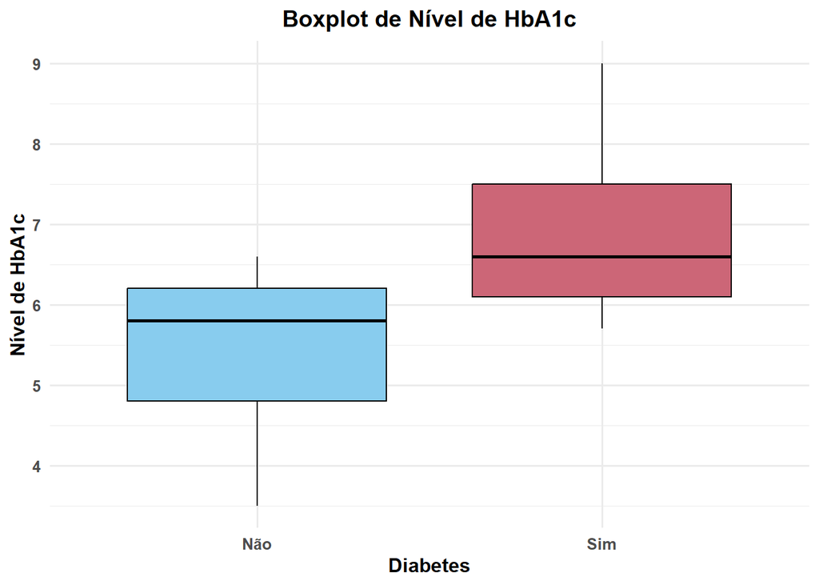

```r
# Boxplot
ggplot(dados, aes(x = factor(diabetes), y = HbA1c_level, fill = factor(diabetes))) +
  geom_boxplot(color = "black") +
  scale_fill_manual(values = c("#88CCEE", "#CC6677")) +
  labs(x = "Diabetes", y = "Nível de HbA1c") +
  scale_x_discrete(breaks = c(0,1), label = c("Não", "Sim")) +
  guides(fill = "none")+
  ggtitle("Boxplot de Nível de HbA1c") +
  theme()
```

É possível observar uma relação muito mais clara entre o nível de hemoglobina glicada com o diagnóstico de diabetes do que as variáveis consideradas anteriormente. Notamos que a faixa de valores coincidente para os dois grupos é bem pequena.

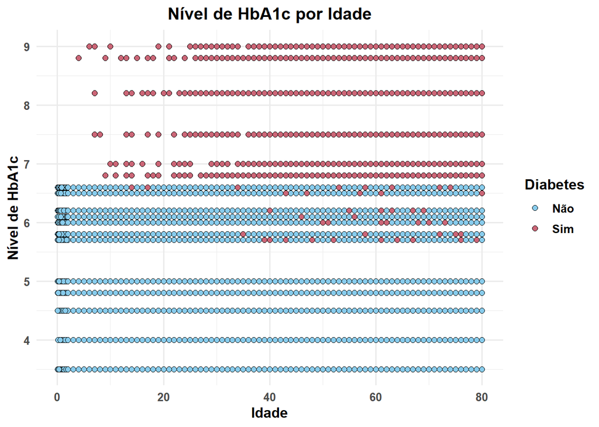

```r
# Scatterplot
ggplot(dados, aes(x = age, y = HbA1c_level, fill = factor(diabetes))) +
  geom_point(shape = 21, size = 2) +
  labs(x = "Idade", y = "Nível de HbA1c", fill = "Diabetes") +
  ggtitle("Nível de HbA1c por Idade") +
  scale_fill_manual(values = c("#88CCEE", "#CC6677"),
                    breaks = c(0,1), labels = c("Não","Sim")) +
  theme()
```

Agora, analisando o nível de glicose no sangue

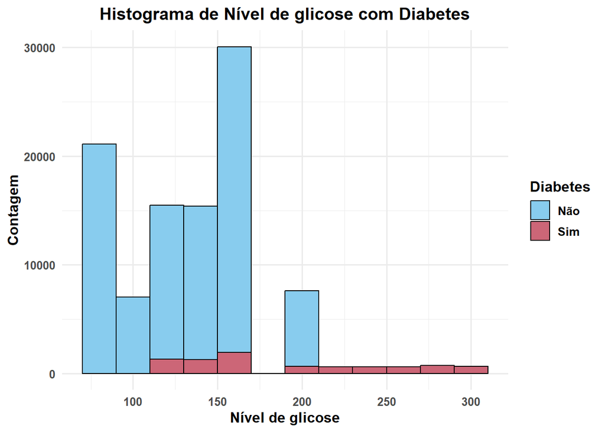

```r
# Histograma
ggplot() +
  geom_histogram(data = dados, aes(x = blood_glucose_level, fill = "Não"),
                 binwidth = 20, color = "black") +
  geom_histogram(data = subset(dados, diabetes == 1),
                 aes(x = blood_glucose_level, fill = "Sim"),
                 binwidth = 20, color = "black") +
  labs(x = "Nível de glicose", y = "Contagem", fill = "Diabetes") +
  scale_fill_manual(values = c("Não" = "#88CCEE", "Sim" = "#CC6677")) +
  ggtitle("Histograma de Nível de glicose com Diabetes") +
  theme()
```

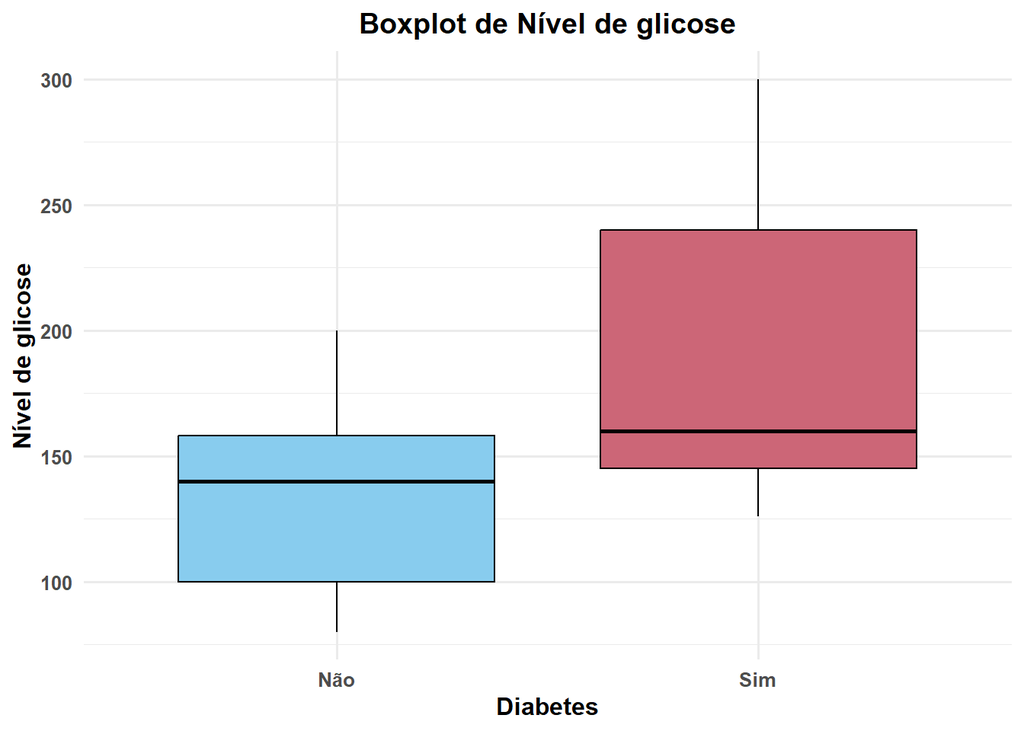

```r
# Boxplot
ggplot(dados, aes(x = factor(diabetes), y = blood_glucose_level, fill = factor(diabetes))) +
  geom_boxplot(color = "black") +
  scale_fill_manual(values = c("#88CCEE", "#CC6677")) +
  labs(x = "Diabetes", y = "Nível de glicose") +
  scale_x_discrete(breaks = c(0,1), label = c("Não", "Sim")) +
  guides(fill = "none")+
  ggtitle("Boxplot de Nível de glicose") +
  theme()
```

Observamos uma relação semelhante a do nível de HbA1c, em que os grupos possuem um pequeno intervalo de valores coincidentes.

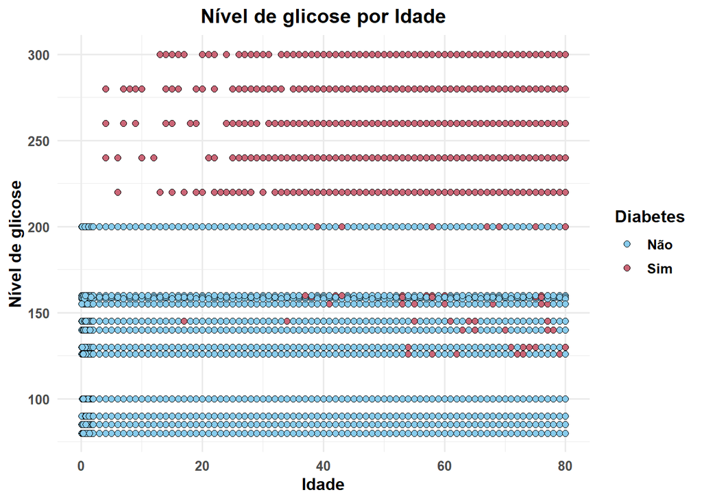

```r
# Scatterplot
ggplot(dados, aes(x = age, y = blood_glucose_level, fill = factor(diabetes))) +
  geom_point(shape = 21, size = 2) +
  labs(x = "Idade", y = "Nível de glicose", fill = "Diabetes") +
  ggtitle("Nível de glicose por Idade") +
  scale_fill_manual(values = c("#88CCEE", "#CC6677"),
                    breaks = c(0,1), labels = c("Não","Sim")) +
  theme()
```

E também, assim como o nível de hemoglobina, é possível visulizar uma delimitação significativa no valor do nível de glicose sanguínea dos dois grupos de diagnóstico de diabetes.

# Correlação de diabetes com as variáveis

Por fim, após analisarmos a relação de cada uma das variáveis com a diabetes, reafirmamos o que foi observado através de um mapa de correlação da diabetes com cada uma das variáveis (exceto apenas o histórico de tabagismo):

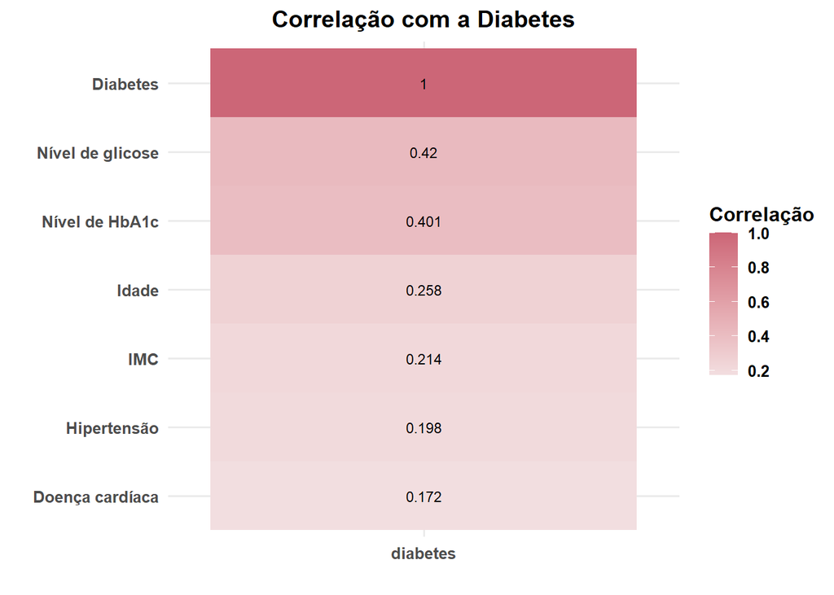

```r
dados %>%
  select(age, hypertension, heart_disease, bmi, HbA1c_level, blood_glucose_level, diabetes) %>%
  cor() %>%
  as.data.frame() %>%
  tibble::rownames_to_column(var = "Variable") %>%
  filter(Variable == "diabetes") %>%
  pivot_longer(cols = -Variable, names_to = "Variable2", values_to = "Correlation") %>%
  mutate(Variable2 = reorder(Variable2, Correlation)) %>%
  ggplot(aes(Variable, Variable2, fill = Correlation)) +
  geom_tile() +
  geom_text(aes(label = round(Correlation, 3)), color = "black", size = 3) +
  labs(title = "Correlação com a Diabetes",
       x = "", y = "", fill = "Correlação") +
  scale_fill_gradient2(low = "#3C61A0", mid = "#F7F7F7", high = "#CC6677", midpoint = 0) +
  scale_y_discrete(labels = c("Doença cardíaca", "Hipertensão", "IMC", "Idade", "Nível de HbA1c", "Nível de glicose", "Diabetes")) +
  theme()
```

E, assim, podemos notar que, conforme já verificado, as maiores correlações da diabetes são com o nível de glicose e o nível de HbA1c, e menores para as demais variáveis.

# Conclusões

- Observamos que a prevalência de diabetes é maior em homens em comparação com mulheres. Além disso, pacientes com hipertensão e doenças cardíacas têm maior propensão a ter diabetes.
- Verificamos que o histórico de tabagismo apresenta uma relação sutil com o diagnóstico de diabetes, sem uma associação clara.
- Em relação às variáveis numéricas, observamos que a idade e o IMC têm uma associação positiva com o diagnóstico de diabetes. Indivíduos com idade acima de 40 anos e IMC acima de 30 apresentam maior incidência da doença.
- Os níveis de HbA1c e glicose no sangue apresentaram uma relação mais clara com o diagnóstico de diabetes. Valores elevados dessas variáveis estão associados a um maior risco de desenvolver a doença.
- Ao considerar a correlação da diabetes com as variáveis, confirmamos que as maiores correlações estão com os níveis de glicose e HbA1c, reforçando sua importância como indicadores da doença.
- Com base nessas análises, é possível concluir que fatores como idade, gênero, hipertensão, doenças cardíacas, níveis de HbA1c e glicose no sangue desempenham um papel significativo na incidência de diabetes. Esses resultados podem auxiliar na identificação de indivíduos em risco e no desenvolvimento de estratégias de prevenção e tratamento personalizados.